# Participation in the elections on the local level

# 3.2. Model diagnostics

**Provide model accuracy, specificity, sensitivity; AUC. Model correction if needed.**

Chance of regular voting is 39,2%.

ROC curve: is a graph that displays the sensitivity and specificity of a logistic regression model (the more the ROC curve spans the upper left corner of the graph, the better the model categorizes the data).

- AUC (area under the curve): how much the model is capable of distinguishing between classes; higher the AUC, better the model is at predicting class True (1) as True and False (0) as False. Our model has AUC of 0.66. In general, the predictive ability of the model is close to be acceptable.

```r
prop.table(table(Mongolia_WVS_EVS$vote))
```

```
##
##         0         1
## 0.6075838 0.3924162
```

```r
Mongolia_WVS_EVS$yhat <- predict.glm(model_final, type = 'response')

Mongolia_WVS_EVS$yhat1<-ifelse(Mongolia_WVS_EVS$yhat<0.5, 0, 1)
table(Mongolia_WVS_EVS$vote, Mongolia_WVS_EVS$yhat1)
```

```
##
##       0   1
##   0 584 105
##   1 239 206
```

```r
library(ROSE)
accuracy.meas(Mongolia_WVS_EVS$vote, Mongolia_WVS_EVS$yhat, threshold = 0.5)
```

```
##
## Call:
## accuracy.meas(response = Mongolia_WVS_EVS$vote, predicted = Mongolia_WVS_EVS$yhat,
##     threshold = 0.5)
##
## Examples are labelled as positive when predicted is greater than 0.5
##
## precision: 0.662
## recall: 0.463
## F: 0.272
```

```r
library(caret)
confusionMatrix(reference = Mongolia_WVS_EVS$vote, as.factor(Mongolia_WVS_EVS$yhat1),
                 positive = "1")
```

```
## Confusion Matrix and Statistics
##
##           Reference
## Prediction   0   1
##          0 584 239
##          1 105 206
##
##                Accuracy : 0.6966
##                  95% CI : (0.669, 0.7233)
##     No Information Rate : 0.6076
##     P-Value [Acc > NIR] : 2.613e-10
##
##                   Kappa : 0.328
##
##  Mcnemar's Test P-Value : 7.452e-13
##
##             Sensitivity : 0.4629
##             Specificity : 0.8476
##          Pos Pred Value : 0.6624
##          Neg Pred Value : 0.7096
##              Prevalence : 0.3924
##          Detection Rate : 0.1817
##    Detection Prevalence : 0.2743
##       Balanced Accuracy : 0.6553
##
##        'Positive' Class : 1
##
```

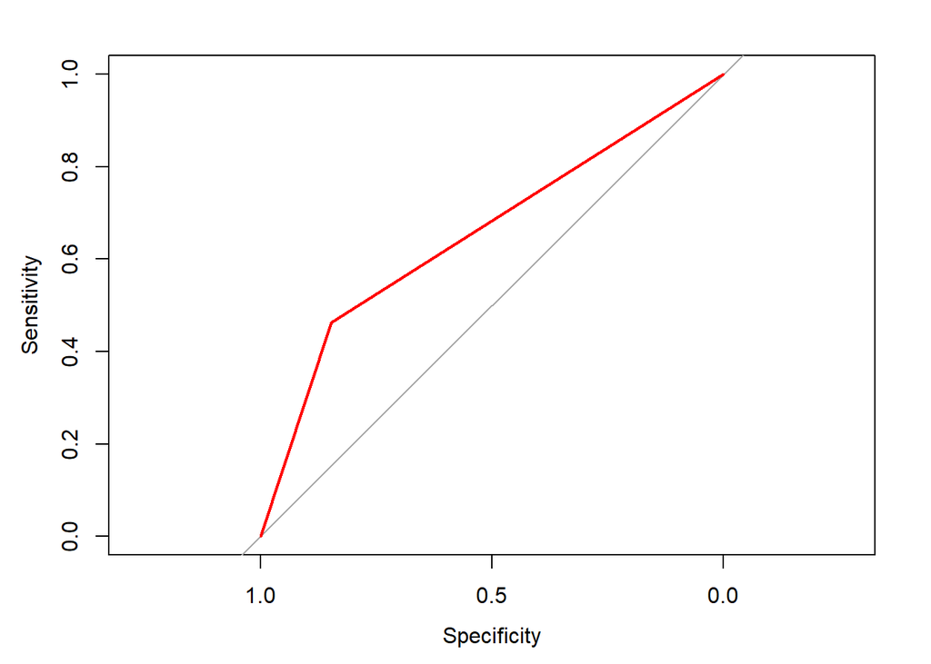

```r
library(pROC)
f1 = roc(Mongolia_WVS_EVS$vote, Mongolia_WVS_EVS$yhat1)
plot(f1, col="red")
```

```r
auc(f1)
```

```
## Area under the curve: 0.6553
```

# 3.3. Interaction effect.

**Add at least one interaction term into your model. Draw a plot. Interpret your results.**

Since we have already met with multicolleniality before, we will create an interaction effect with those variables: government_conf and parliament_conf.

In this model interaction is statistically significant since the p-value is less than 0.05. AIC of this model is the lowest - 1364.9.

```r
Mongolia_WVS_EVS <- within(Mongolia_WVS_EVS,
                           parliament_conf <- relevel(parliament_conf,
                                                      ref = "Not confident"))

model_int <-glm(vote ~ age + education + religion + life_sat + income +
                pol_interest + government_resp + government_conf*parliament_conf +
                  petition + boycott,
              data = Mongolia_WVS_EVS, family = "binomial")
summary(model_int)
```

```
##
## Call:
## glm(formula = vote ~ age + education + religion + life_sat +
##     income + pol_interest + government_resp + government_conf *
##     parliament_conf + petition + boycott, family = "binomial",
##     data = Mongolia_WVS_EVS)
##
## Deviance Residuals:
##     Min       1Q   Median       3Q      Max
## -1.9799  -0.9445  -0.6295   1.0643   2.4924
##
## Coefficients:
##                                                   Estimate Std. Error z value
## (Intercept)                                       -1.30983    0.38418  -3.409
## age30 - 49                                         0.44960    0.16031   2.805
## age55 and more                                     0.77210    0.18355   4.206
## educationTertiary education                        0.40390    0.13977   2.890
## religionReligious person                           0.76836    0.13795   5.570
## life_sat                                           0.10941    0.03707   2.952
## income                                            -0.10398    0.03786  -2.747
## pol_interestInterested                             0.48910    0.14163   3.453
## government_resp                                   -0.06505    0.02706  -2.404
## government_confConfident                           0.39975    0.18838   2.122
## parliament_confConfident                          -1.18607    0.34073  -3.481
## petitionHave an experience                         0.74302    0.14027   5.297
## boycottHave done or might                         -0.64220    0.15220  -4.220
## government_confConfident:parliament_confConfident  0.93851    0.40369   2.325
##                                                   Pr(>|z|)
## (Intercept)                                       0.000651 ***
## age30 - 49                                        0.005038 **
## age55 and more                                    2.60e-05 ***
## educationTertiary education                       0.003856 **
## religionReligious person                          2.55e-08 ***
## life_sat                                          0.003160 **
## income                                            0.006023 **
## pol_interestInterested                            0.000553 ***
## government_resp                                   0.016210 *
## government_confConfident                          0.033835 *
## parliament_confConfident                          0.000500 ***
## petitionHave an experience                        1.18e-07 ***
## boycottHave done or might                         2.45e-05 ***
## government_confConfident:parliament_confConfident 0.020083 *
## ---
## Signif. codes:  0 '***' 0.001 '**' 0.01 '*' 0.05 '.' 0.1 ' ' 1
##
## (Dispersion parameter for binomial family taken to be 1)
##
##     Null deviance: 1519.1  on 1133  degrees of freedom
## Residual deviance: 1336.9  on 1120  degrees of freedom
## AIC: 1364.9
##
## Number of Fisher Scoring iterations: 4
```

```r
exp(model_int$coefficients)
```

```
##                                       (Intercept)
##                                         0.2698647
##                                        age30 - 49
##                                         1.5676795
##                                    age55 and more
##                                         2.1643074
##                       educationTertiary education
##                                         1.4976566
##                          religionReligious person
##                                         2.1562366
##                                          life_sat
##                                         1.1156179
##                                            income
##                                         0.9012458
##                            pol_interestInterested
##                                         1.6308546
##                                   government_resp
##                                         0.9370194
##                          government_confConfident
##                                         1.4914462
##                          parliament_confConfident
##                                         0.3054189
##                        petitionHave an experience
##                                         2.1022833
##                         boycottHave done or might
##                                         0.5261351
## government_confConfident:parliament_confConfident
##                                         2.5561578
```

We are interested in part where respondent is confident in parliament. So if they are not confident in government, their predicted probability of regular voting is 0.15, but if they are confident in both institutions, probability of regular voting increase to 0.41. So, the difference is 26%.

```r
eff_2<-allEffects(model_int)
eff_2
```

```
##  model: vote ~ age + education + religion + life_sat + income + pol_interest +
##     government_resp + government_conf * parliament_conf + petition +
##     boycott
##
##  age effect
## age
##     15 - 29     30 - 49 55 and more
##   0.2654402   0.3616325   0.4388621
##
##  education effect
## education
## Secondary education or less          Tertiary education
##                   0.2995466                   0.3904178
##
##  religion effect
## religion
## Not a religious person       Religious person
##              0.2879618              0.4658185
##
##  life_sat effect
## life_sat
##         1         3         6         8        10
## 0.2297145 0.2706934 0.3400925 0.3907728 0.4439249
##
##  income effect
## income
##         1         3         6         8        10
## 0.4631389 0.4120089 0.3390347 0.2941001 0.2528428
##
##  pol_interest effect
## pol_interest
## Not interested     Interested
##      0.3144525      0.4279351
##
##  government_resp effect
## government_resp
##         1         3         6         8        10
## 0.4061438 0.3751859 0.3306633 0.3025278 0.2757999
##
##  petition effect
## petition
##      No experience Have an experience
##          0.2771234          0.4462704
##
##  boycott effect
## boycott
##     Would never do Have done or might
##          0.4579532          0.3077237
##
##  government_conf*parliament_conf effect
##                parliament_conf
## government_conf Not confident Confident
##   Not confident     0.3712582 0.1527887
##   Confident         0.4682735 0.4074197
```

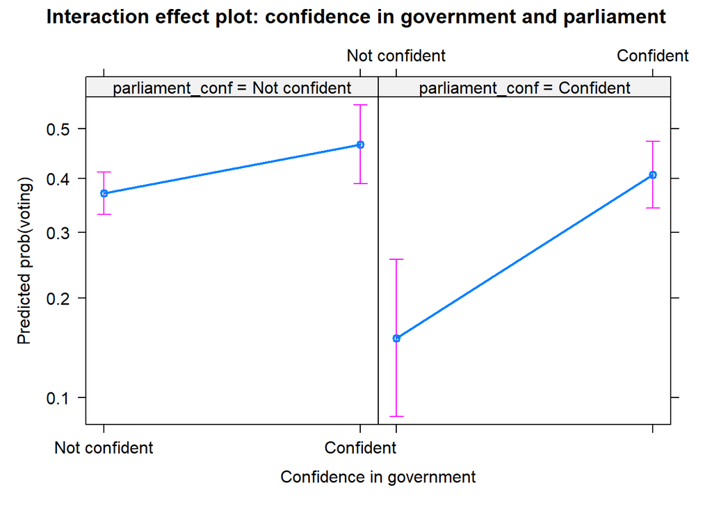

```r
plot(eff_2, 'government_conf:parliament_conf',
     ylab="Predicted prob(voting)",
     xlab = "Confidence in government",
     main = "Interaction effect plot: confidence in government and parliament")
```

## 4. Decision tree.

**For the same variables you tested for your model, run a decision tree of the preferred type. Describe the results. Are they different from what you observed in the regression? (2 points)**

Regular participation in voting depends primarily on whether a person is religious or not and then it depends on attitudes towards government responsibility.

Also age is important factor, which appears in several branches. Moreover, income, level of life satisfaction, confidence in government and experience in signing petition are determine the regularity of participation in elections at the local level.

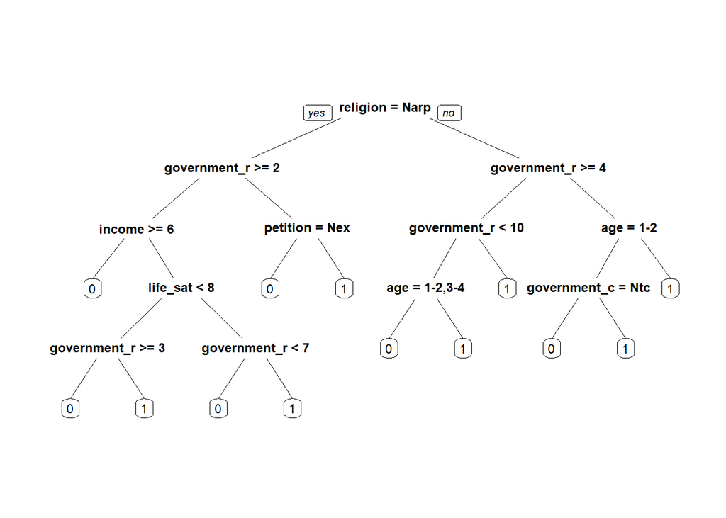

```r
tree <- rpart(vote ~ age + education + religion + life_sat + income +
                pol_interest + government_resp + government_conf + petition +
                 boycott,
              data = Mongolia_WVS_EVS, control=rpart.control(cp=.0001))
best <- 0.007
pruned_tree <- prune(tree, cp=best)
prp(pruned_tree)
```

## 5. Run factor analysis for the variables on Confidence (E069_).

**Describe the factor structure you got: how many factors did you get? What do they mean? Add at least one of those factors in your final model, interpret its effect.**

Let’s select variables for factor analysis, rename them and change the class into numeric.

```r
library(polycor)
library(psych)

Mongolia_factors <- Mongolia_WVS_EVS[c("E069_01", "E069_02", "E069_04",
                              "E069_05", "E069_06", "E069_07", "E069_08",
                              "E069_11", "E069_12", "E069_13","E069_14", "E069_17")]

lookup <- c(c_churches = "E069_01", c_armed_forces = "E069_02", c_press = "E069_04",
            c_labour_unions = "E069_05", c_police = "E069_06",
            c_parliament ="E069_07", c_civil_services = "E069_08",
            c_government = "E069_11", c_political_parties = "E069_12",
            c_major_companies = "E069_13", c_env_movemnt = "E069_14",
            c_justice_system = "E069_17")

Mongolia_factors <- rename(Mongolia_factors, all_of(lookup))
names(Mongolia_factors)
```

```
##  [1] "c_churches"          "c_armed_forces"      "c_press"
##  [4] "c_labour_unions"     "c_police"            "c_parliament"
##  [7] "c_civil_services"    "c_government"        "c_political_parties"
## [10] "c_major_companies"   "c_env_movemnt"       "c_justice_system"
```

```r
class(Mongolia_factors$c_churches)
```

```
## [1] "haven_labelled" "vctrs_vctr"     "double"
```

```r
Mongolia_factors_2 <-as.data.frame(lapply(Mongolia_factors, as.factor))
class(Mongolia_factors_2$c_churches)
```

```
## [1] "factor"
```

Based on correlation matrix we can see that some variables positively correlate with each other (for instance, police and justice system, or parliament and political parties). And some variables are not correlate with each other (for example, churches and parliament, environmental protection movement and government).

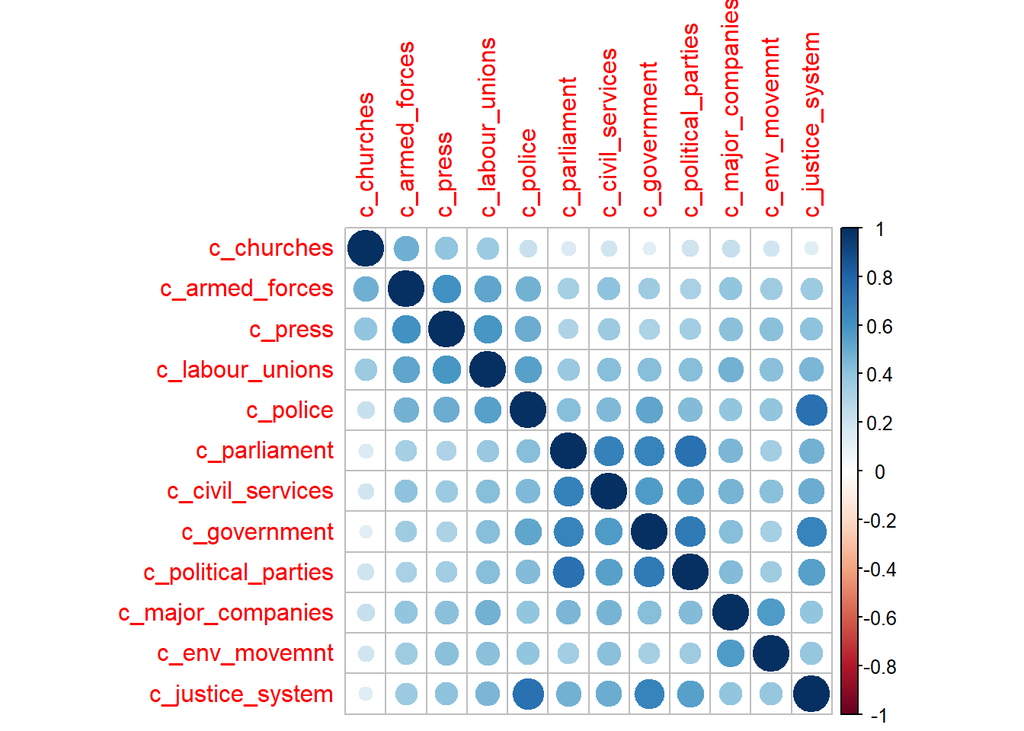

```r
library(polycor)
corMongolia <- hetcor(Mongolia_factors_2)
corrplot::corrplot(corMongolia$correlations)
```

In parallel analysis, we can see that 4 factors in the “Factor Analysis” lie above the corresponding simulated data line and 2 components in the “Principal Components” parallel analysis lie above the corresponding simulated data line. So, we will have two factors/components.

```r
nrow(Mongolia_factors_2)
```

```
## [1] 1134
```

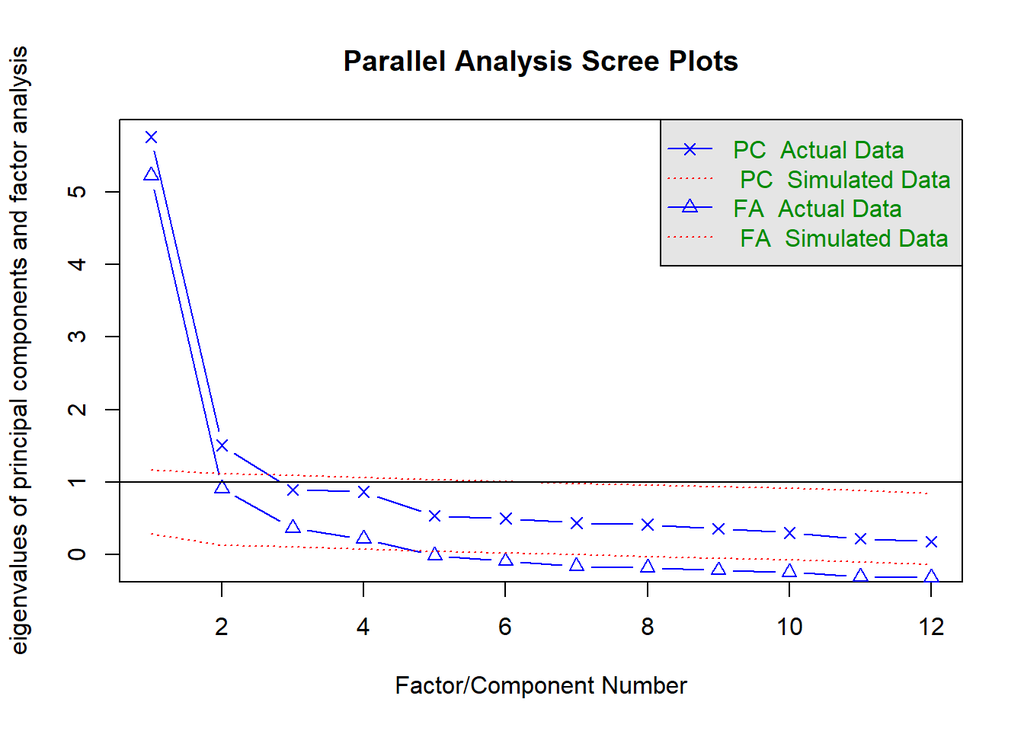

```
## Parallel analysis suggests that the number of factors =  4  and the number of components =  2
```

```r
fa.parallel(corMongolia$correlations, 1134)
```

So, we got 2 factors: the first one (MR1) consists mostly of confidence in political institutions and the second one includes mostly confidence in civil_society_institutions.

```r
Mongolia_factors_2 <-as.data.frame(lapply(Mongolia_factors, as.numeric))
fa(Mongolia_factors_2, 2, cor="mixed")
```

```
## Factor Analysis using method =  minres
## Call: fa(r = Mongolia_factors_2, nfactors = 2, cor = "mixed")
## Standardized loadings (pattern matrix) based upon correlation matrix
##                       MR1   MR2   h2   u2 com
## c_churches          -0.16  0.60 0.28 0.72 1.1
## c_armed_forces      -0.01  0.76 0.57 0.43 1.0
## c_press             -0.04  0.80 0.61 0.39 1.0
## c_labour_unions      0.15  0.66 0.56 0.44 1.1
## c_police             0.39  0.42 0.51 0.49 2.0
## c_parliament         0.86 -0.07 0.68 0.32 1.0
## c_civil_services     0.63  0.15 0.53 0.47 1.1
## c_government         0.87 -0.04 0.71 0.29 1.0
## c_political_parties  0.81  0.00 0.65 0.35 1.0
## c_major_companies    0.34  0.38 0.41 0.59 2.0
## c_env_movemnt        0.25  0.40 0.33 0.67 1.7
## c_justice_system     0.61  0.19 0.54 0.46 1.2
##
##                        MR1  MR2
## SS loadings           3.56 2.83
## Proportion Var        0.30 0.24
## Cumulative Var        0.30 0.53
## Proportion Explained  0.56 0.44
## Cumulative Proportion 0.56 1.00
##
##  With factor correlations of
##      MR1  MR2
## MR1 1.00 0.56
## MR2 0.56 1.00
##
## Mean item complexity =  1.3
## Test of the hypothesis that 2 factors are sufficient.
##
## df null model =  66  with the objective function =  6.51 with Chi Square =  7344.67
## df of  the model are 43  and the objective function was  0.88
##
## The root mean square of the residuals (RMSR) is  0.06
## The df corrected root mean square of the residuals is  0.07
##
## The harmonic n.obs is  1134 with the empirical chi square  454.55  with prob <  4e-70
## The total n.obs was  1134  with Likelihood Chi Square =  986.74  with prob <  8.2e-179
##
## Tucker Lewis Index of factoring reliability =  0.801
## RMSEA index =  0.139  and the 90 % confidence intervals are  0.132 0.147
## BIC =  684.3
## Fit based upon off diagonal values = 0.98
## Measures of factor score adequacy
##                                                    MR1  MR2
## Correlation of (regression) scores with factors   0.95 0.93
## Multiple R square of scores with factors          0.90 0.86
## Minimum correlation of possible factor scores     0.81 0.71
```

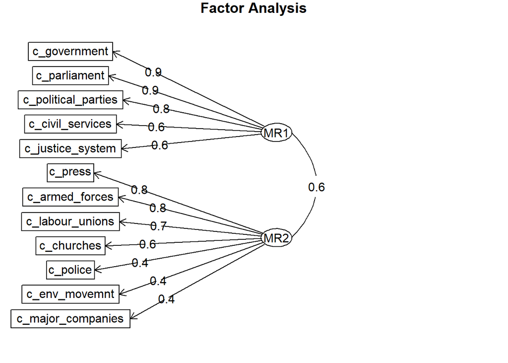

```r
fa.diagram(fa(Mongolia_factors_2, 2, cor="mixed"))
```

```r
c_political_institutions <- Mongolia_factors_2[c('c_government',
                                                 'c_parliament',
                                                 'c_political_parties',
                                                 'c_civil_services',
                                                 'c_justice_system')]

c_civil_society_institutions <- Mongolia_factors_2[c('c_press',
                                                     'c_armed_forces',
                                                     'c_labour_unions',
                                                     'c_churches',
                                                     'c_police',
                                                     'c_env_movemnt',
                                                     'c_major_companies')]
```

Let’s save them in our initial dataset and rename.

```r
fa2 <-fa(Mongolia_factors_2, 2, cor="mixed", scores=T)
fa2<- fa2$scores
Mongolia_WVS_EVS<- cbind(Mongolia_WVS_EVS, fa2)
Mongolia_WVS_EVS <- rename(Mongolia_WVS_EVS, c_political_institutions = MR1)
Mongolia_WVS_EVS <- rename(Mongolia_WVS_EVS, c_civil_society_institutions = MR2)
```